# Pract_ML_Project

Sudip Goswami

July 28, 2017

### Project Goal:

The data for this project comes from http://groupware.les.inf.puc-rio.br/har. Here, six participants were asked to barbell lifts correctly and incorrectly in 5 different ways and data was recorded on the belt, forearm, arm and dumbell. The goal of this project is to predict the manner in which the six participants did the exercise.

### Datasets:

There were two sets of data, a. pml-training.csv and b. pml-testing.csv, which were downloaded from the websites https://d396qusza40orc.cloudfront.net/predmachlearn/pml-training.csv and https://d396qusza40orc.cloudfront.net/predmachlearn/pml-testing.csv respectively. The testing data is part of the quiz. Here we will mainly focus on the training data.

### Preprocessing of Data:

A cursory look at the training data shows that it has many variables with a lot of missing values or NA. So, first, these variables are removed from the training data.

It is further observed that there are many factor variables and many of them have more than 53 levels, as I am planning to use random forest algorithm for building the model, those factor variables are also removed.

#### Splitting the training data into train and test set

```r
library(caret)
set.seed(100)
inTrain<- createDataPartition(y= pml_3$classe, p = 0.7, list = FALSE)
train <- pml_3[inTrain,]
test <- pml_3[-inTrain,]
x<- train[,-53]
y <-train[,53]
```

For building the model, 10-fold cross validation is used.

#### Building the model

```r
modFitControl <-trainControl(method = "cv", number = 10)
set.seed(100)
modFit <- train(x,y, method = "rf", data = pml_3, trControl = modFitControl)
```

To get OOB(out of bag) error estimate and confusion matrix

```r
modFit$finalModel
```

```
##
## Call:
##  randomForest(x = x, y = y, mtry = param$mtry, data = ..1)
##                Type of random forest: classification
##                      Number of trees: 500
## No. of variables tried at each split: 2
##
##         OOB estimate of  error rate: 0.79%
## Confusion matrix:
##      A    B    C    D    E  class.error
## A 3904    1    0    0    1 0.0005120328
## B   13 2636    9    0    0 0.0082768999
## C    0   29 2365    2    0 0.0129382304
## D    0    0   40 2210    2 0.0186500888
## E    0    1    3    7 2514 0.0043564356
```

As can be seen the OOB error estimate is 0.79%

To get accuracy and kappa values versus mtry

```r
modFit
```

```
## Random Forest
##
## 13737 samples
##    52 predictor
##     5 classes: 'A', 'B', 'C', 'D', 'E'
##
## No pre-processing
## Resampling: Cross-Validated (10 fold)
## Summary of sample sizes: 12363, 12364, 12362, 12363, 12363, 12362, ...
## Resampling results across tuning parameters:
##
##   mtry  Accuracy   Kappa
##    2    0.9909015  0.9884899
##   27    0.9907558  0.9883055
##   52    0.9836214  0.9792814
##
## Accuracy was used to select the optimal model using  the largest value.
## The final value used for the model was mtry = 2.
```

As shown here the final value used for the model was mtry = 2

To get accuracies on hold-out folds

```r
modFit$resample
```

```
##     Accuracy     Kappa Resample
## 1  0.9956300 0.9944724   Fold02
## 2  0.9905386 0.9880325   Fold01
## 3  0.9912727 0.9889588   Fold03
## 4  0.9869091 0.9834345   Fold06
## 5  0.9919942 0.9898717   Fold05
## 6  0.9883552 0.9852702   Fold04
## 7  0.9927114 0.9907797   Fold07
## 8  0.9905317 0.9880226   Fold10
## 9  0.9876274 0.9843475   Fold09
## 10 0.9934450 0.9917093   Fold08
```

To get cross-validated Confusion Matrix

```r
confusionMatrix.train(modFit)
```

```
## Cross-Validated (10 fold) Confusion Matrix
##
## (entries are percentual average cell counts across resamples)
##
##           Reference
## Prediction    A    B    C    D    E
##          A 28.4  0.2  0.0  0.0  0.0
##          B  0.0 19.1  0.2  0.0  0.0
##          C  0.0  0.1 17.2  0.3  0.0
##          D  0.0  0.0  0.0 16.1  0.1
##          E  0.0  0.0  0.0  0.0 18.3
##
##  Accuracy (average) : 0.9909
```

The average accuracy is 0.9909 i.e 99.09%

### Prediction the testing Dataset

```r
testing <- read.csv("pml-testing.csv")
pred1 <- predict(modFit, newdata = testing)
pred1
```

```
##  [1] B A B A A E D B A A B C B A E E A B B B
## Levels: A B C D E
```

All 20 predictions are correct.

Now let us see the relative importance of the 52 predictors used for this model in a plot

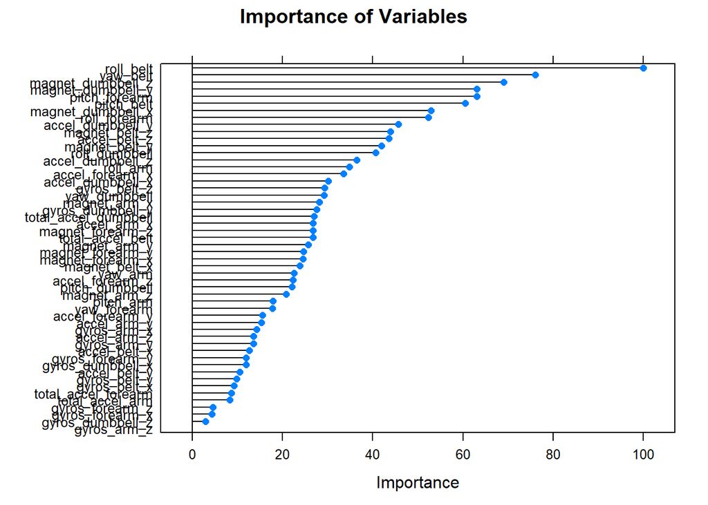

```r
plot(varImp(modFit), main = "Importance of Variables", top = 52) #All 52 predictors
```

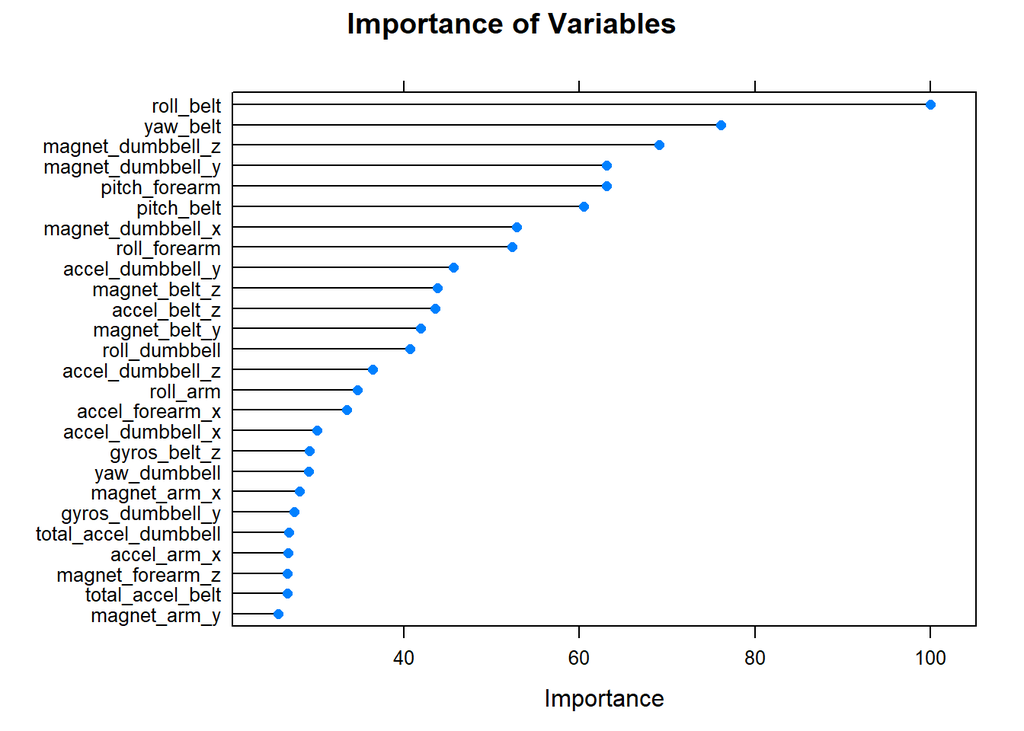

```r
plot(varImp(modFit), main = "Importance of Variables", top = 26)#First 26 predictors
```

Finally, the model is tested on the hold-out test data which was not used for building the model

```r
pred2<- predict(modFit, newdata = test)
table(test$classe, pred2)
```

```
##    pred2
##        A    B    C    D    E
##   A 1673    1    0    0    0
##   B    8 1128    3    0    0
##   C    0    5 1020    1    0
##   D    0    0   13  950    1
##   E    0    0    0    1 1081
```

```r
(1673+1128+1020+950+1081)/nrow(test)
```

```
## [1] 0.9943925
```

```r
1-0.9943925
```

```
## [1] 0.0056075
```

So, the out of sample accuracy of the model based on the prediction on the test data is 0.9943925 i.e. around 99.44%, hence the out of sample error rate is approximately 0.56%. This concludes this analysis.